# Functions

23/10/2019

## Outline

- What are functions
- Writing your own Functions
- Debugging
- Pitfalls

## Why Functions?

- Reduce the amount of copy & pasting required
- Let computers do what they do best: repeatitive tasks
- Code is more readable

## Functions

- You have used Functions in the past like `sum()`, `mean()`, `filter()`
- Under the hood these are powered by lines of R code
- you can see this by going command + click the function name
- does not work for all functions (ie base R)

```r
#filter
#mean
```

## Basic Structure

```r
Name_of_function <- function(ingredient_1){
  # Body of your function
  # where your R code goes
  # "Recipe goes here"
}
```

## 🍰

### Recipe

Pumpkin Pie 🎃

Ingredients:

- Pumpkin
- Egg
- Pie Crust

Recipe:

- Preheat the oven to 350 F
- Whisk together pumpkin, egg
- Pour mixture into pie crust

### R code

```r
Pumpkin_pie <- function(pumpkin, ..., p_crust){
#  1. Preheat the oven to 350 F
#  2. Whisk together pumpkin, egg
#  3. Pour mixture into crust
#  Produces a pi <- automatically `returns`
}
```

## Ex. Function for Area

```r
#fill in the template
#variables in your arguments can be referenced in your body
tri_area <- function(height, base){
  height * base / 2
}
# running it will give you a new function in your environment

tri_area(1, 5)
```

```
[1] 2.5
```

## General rule of thumb:

If you need to copy more than 3 times you should start thinking about writing a function

## Tips for writing functions

[figure not shown]

MVP

## General Steps

- Write some working R code
- Put code into the function format
- Test it
- Fix it until it works

## Challenge 1

Write a function that:

- given the width, depth and height
- calculates the volume of a rectangular prisim

## Debugging - specialized functions

- `debug()`
- `browser()`
- rstudio “red dot” debugger

## Debugging with Print!

```r
debug <- function(height, base){
  1 + 2
  height * base / 2
}

debug(1,2)
```

```
[1] 1
```

```r
debug2 <- function(height, base){
  print(1 + 2)
  height * base / 2
}

debug2(1,2)
```

```
[1] 3
```

```
[1] 1
```

## Pitfalls

- TidyEvaluation (we will focus on this)
- Lexical Scoping (look this up later)

## Pitfalls - Tidy Evaluation

Trying this for ggplot2

```r
library("ggplot2")
```

Using the built in dataset

```r
head(mtcars)
```

```
                   mpg cyl disp  hp drat    wt  qsec vs am gear carb
Mazda RX4         21.0   6  160 110 3.90 2.620 16.46  0  1    4    4
Mazda RX4 Wag     21.0   6  160 110 3.90 2.875 17.02  0  1    4    4
Datsun 710        22.8   4  108  93 3.85 2.320 18.61  1  1    4    1
Hornet 4 Drive    21.4   6  258 110 3.08 3.215 19.44  1  0    3    1
Hornet Sportabout 18.7   8  360 175 3.15 3.440 17.02  0  0    3    2
Valiant           18.1   6  225 105 2.76 3.460 20.22  1  0    3    1
```

## But this doesn’t work

```r
#ggplot(data = mtcars, aes(x = mpg, y = wt)) +
#    geom_point()

multi_graph <- function(cx, cy){
  ggplot(data= mtcars, aes(x = cx, y = cy)) +
    geom_point()
}

#multi_graph(mpg,wt)
```

## Tidyeval to the Rescue

put a {{}} on everything

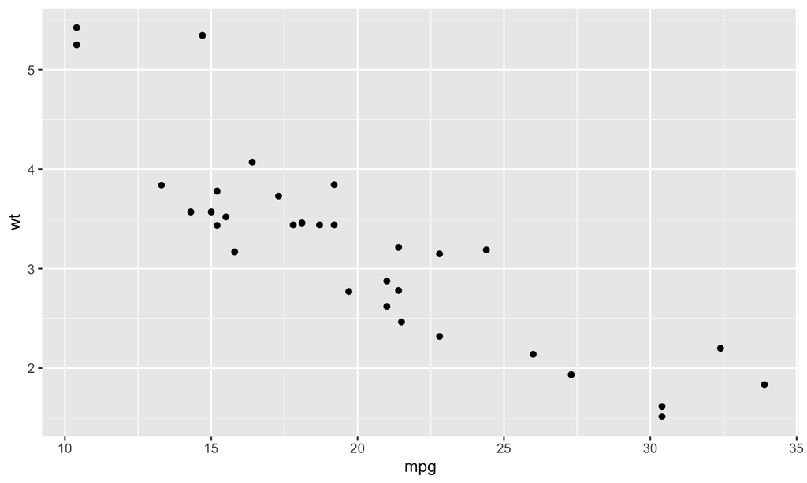

## Challenge 2

Create a function that:

- will plot a graph of any column in the mtcars dataset
- saves the box plot under any name given